# Aerobic Fitness

The goal is to develop an equation to predict fitness (measured by the ability to consume oxygen) based on exercise tests rather than on expensive and cumbersome oxygen consumption measurements. These measurements were made on men involved in a physical fitness course.

The variables are:

- **Age** (years),
- **Weight** (kg),
- **Oxygen** - oxygen intake rate (ml per kg body weight per minute),
- **RunTime** - time to run 1.5 miles (minutes),
- **RestPulse** - heart rate while resting,
- **RunPulse** - heart rate while running (same time oxygen rate measured),
- **MaxPulse** - maximum heart rate recorded while running.

## Exploratory Data Analysis

```r
library("sas7bdat")
```

```r
library(corrplot)
library(lmtest)
library(car)
library(stargazer)
data <- read.sas7bdat("fitness.sas7bdat")
head(data)
```

|  | Age | Weight | Oxygen | RunTime | RestPulse | RunPulse | MaxPulse |
| --- | --- | --- | --- | --- | --- | --- | --- |
| 1 | 44 | 89.47 | 44.609 | 11.37 | 62 | 178 | 182 |
| 2 | 44 | 85.84 | 54.297 | 8.65 | 45 | 156 | 168 |
| 3 | 38 | 89.02 | 49.874 | 9.22 | 55 | 178 | 180 |
| 4 | 40 | 75.98 | 45.681 | 11.95 | 70 | 176 | 180 |
| 5 | 44 | 81.42 | 39.442 | 13.08 | 63 | 174 | 176 |
| 6 | 44 | 73.03 | 50.541 | 10.13 | 45 | 168 | 168 |

```r
summary(data)
```

```
##       Age            Weight          Oxygen         RunTime
##  Min.   :38.00   Min.   :59.08   Min.   :37.39   Min.   : 8.17
##  1st Qu.:44.00   1st Qu.:73.20   1st Qu.:44.96   1st Qu.: 9.78
##  Median :48.00   Median :77.45   Median :46.77   Median :10.47
##  Mean   :47.68   Mean   :77.44   Mean   :47.38   Mean   :10.59
##  3rd Qu.:51.00   3rd Qu.:82.33   3rd Qu.:50.13   3rd Qu.:11.27
##  Max.   :57.00   Max.   :91.63   Max.   :60.05   Max.   :14.03
##    RestPulse        RunPulse        MaxPulse
##  Min.   :40.00   Min.   :146.0   Min.   :155.0
##  1st Qu.:48.00   1st Qu.:163.0   1st Qu.:168.0
##  Median :52.00   Median :170.0   Median :172.0
##  Mean   :53.45   Mean   :169.6   Mean   :173.8
##  3rd Qu.:58.50   3rd Qu.:176.0   3rd Qu.:180.0
##  Max.   :70.00   Max.   :186.0   Max.   :192.0
```

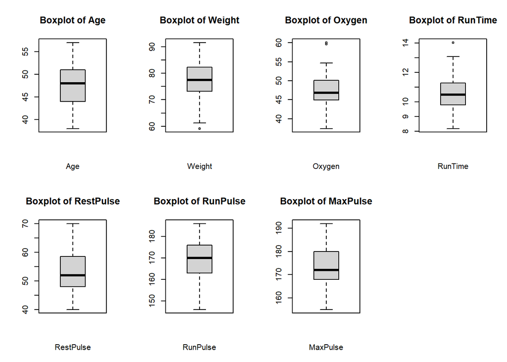

```r
op <- par(mfrow=c(2, 4))

for (col_name in names(data)) {
  boxplot(
    data[[col_name]],
    main=paste("Boxplot of", col_name),
    xlab=col_name,
    horizontal=F
  )
}
```

```r
sum(is.na(data))
```

```
## [1] 0
```

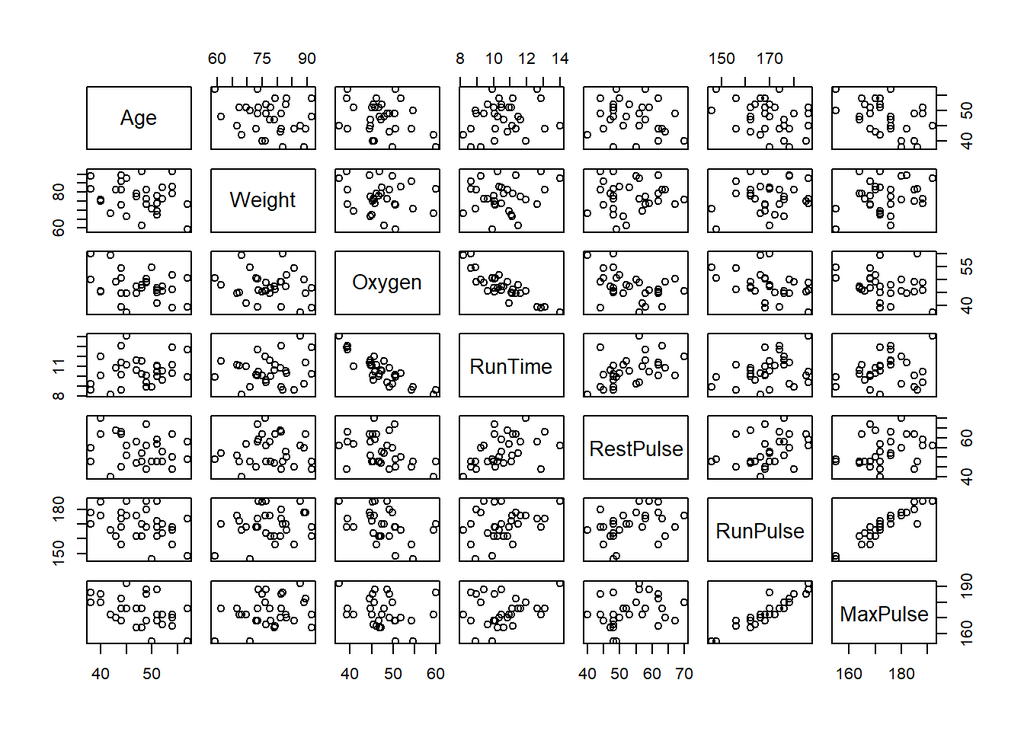

```r
pairs(data)
```

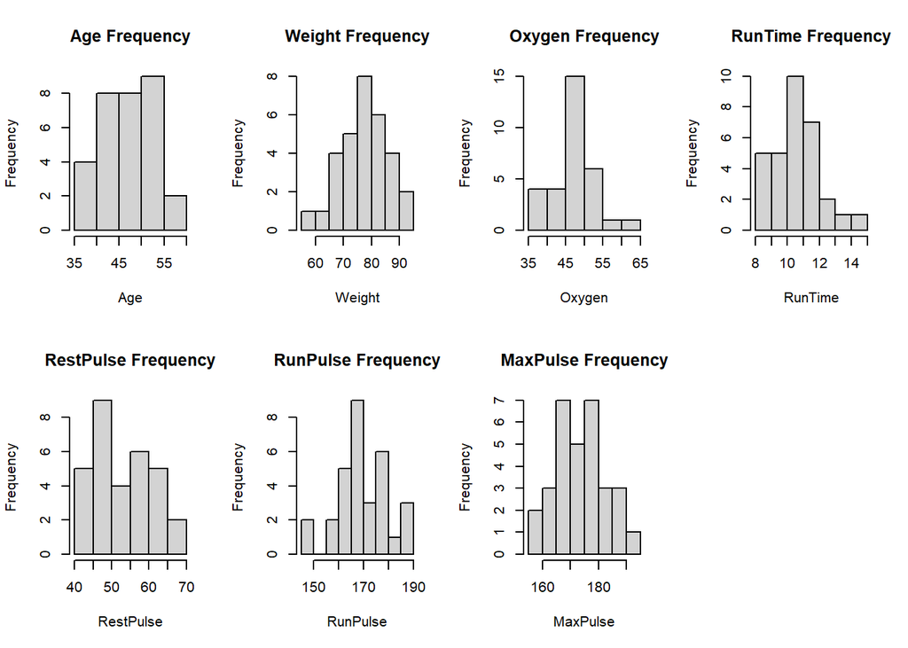

```r
op <- par(mfrow=c(2, 4))

for (col_name in names(data)) {
  hist(
    data[[col_name]],
    main=paste(col_name, "Frequency"),
    xlab=col_name
  )
}
```

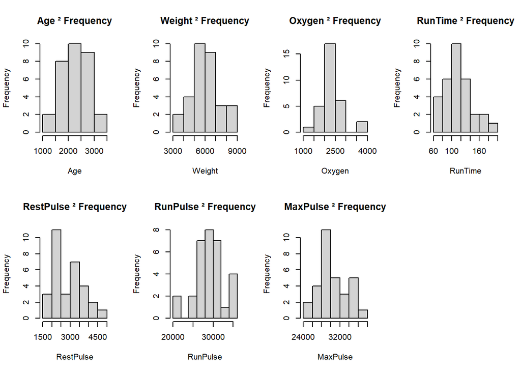

```r
op <- par(mfrow=c(2, 4))

for (col_name in names(data)) {
  hist(
    data[[col_name]] ** 2,
    main=paste(col_name, "² Frequency"),
    xlab=col_name
  )
}
```

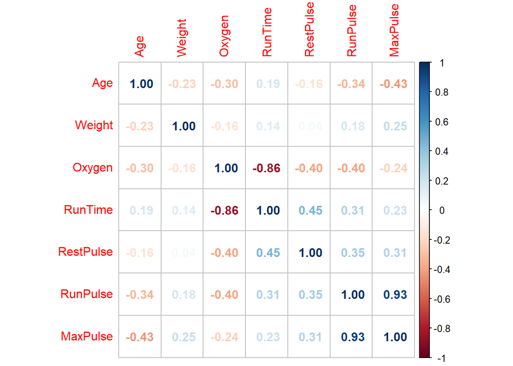

```r
corrplot(cor(data), method = 'number')
```

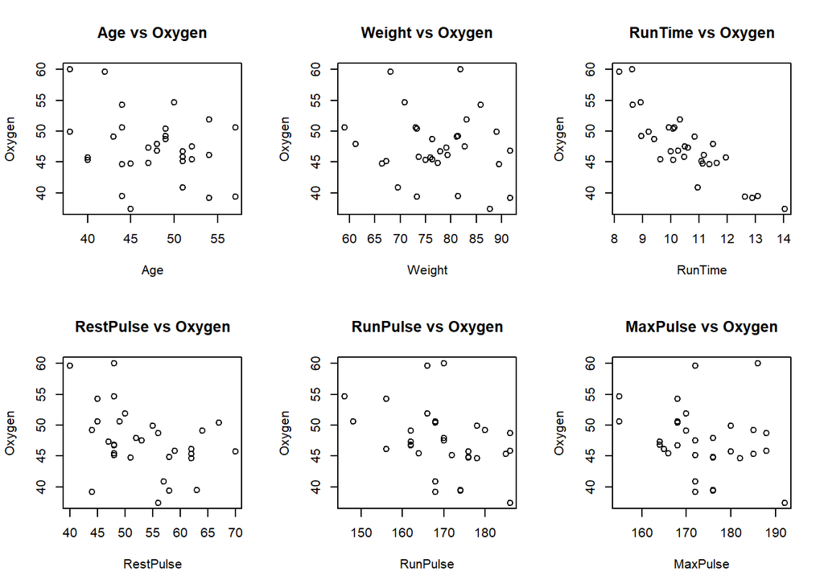

```r
op <- par(mfrow=c(2, 3))

for (col_name in names(data)) {
  if (col_name != "Oxygen") {
    plot(
      data[[col_name]],
      data[["Oxygen"]],
      xlab=col_name,
      ylab="Oxygen",
      main=paste(col_name, "vs Oxygen"))
  }
}
```

## Models

### Intercept-only Model

```r
model_1 <- lm(Oxygen ~ 1, data=data)

summary(model_1)
```

```
##
## Call:
## lm(formula = Oxygen ~ 1, data = data)
##
## Residuals:
##     Min      1Q  Median      3Q     Max
## -9.9878 -2.4113 -0.6018  2.7552 12.6792
##
## Coefficients:
##             Estimate Std. Error t value Pr(>|t|)
## (Intercept)  47.3758     0.9568   49.52   <2e-16 ***
## ---
## Signif. codes:  0 '***' 0.001 '**' 0.01 '*' 0.05 '.' 0.1 ' ' 1
##
## Residual standard error: 5.327 on 30 degrees of freedom
```

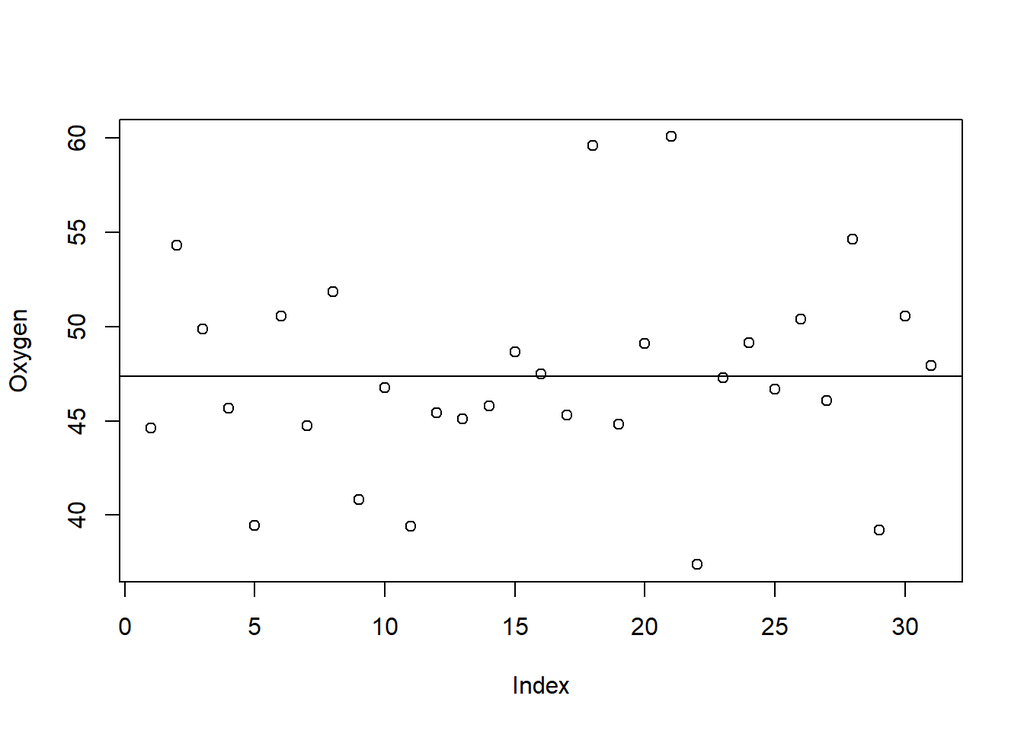

```r
plot(Oxygen ~ 1, data=data)
abline(model_1)
```

```
## hat values (leverages) are all = 0.03225806
##  and there are no factor predictors; no plot no. 5
```

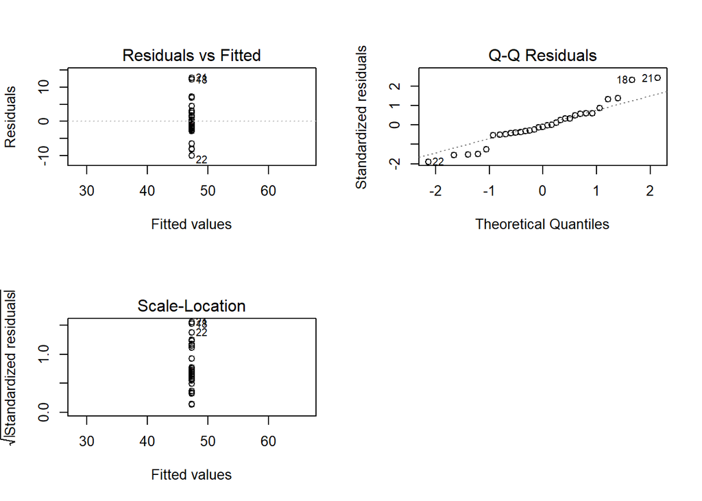

```r
par(mfrow = c(2,2))
plot(model_1)
```

### RunTime Model

```r
model_2 <- lm(Oxygen ~ RunTime, data=data)

summary(model_2)
```

```
##
## Call:
## lm(formula = Oxygen ~ RunTime, data = data)
##
## Residuals:
##     Min      1Q  Median      3Q     Max
## -5.3352 -1.8424 -0.0569  1.5342  6.2033
##
## Coefficients:
##             Estimate Std. Error t value Pr(>|t|)
## (Intercept)  82.4218     3.8553  21.379  < 2e-16 ***
## RunTime      -3.3106     0.3612  -9.166 4.59e-10 ***
## ---
## Signif. codes:  0 '***' 0.001 '**' 0.01 '*' 0.05 '.' 0.1 ' ' 1
##
## Residual standard error: 2.745 on 29 degrees of freedom
## Multiple R-squared:  0.7434, Adjusted R-squared:  0.7345
## F-statistic: 84.01 on 1 and 29 DF,  p-value: 4.585e-10
```

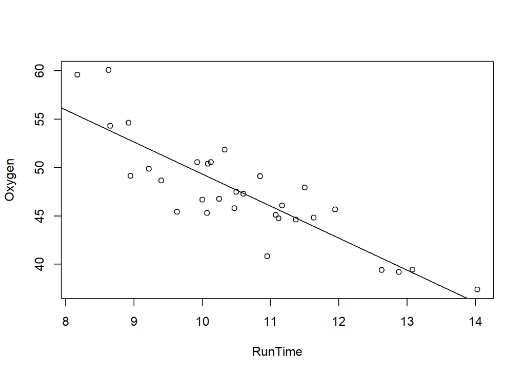

```r
plot(Oxygen ~ RunTime, data=data)
abline(model_2)
```

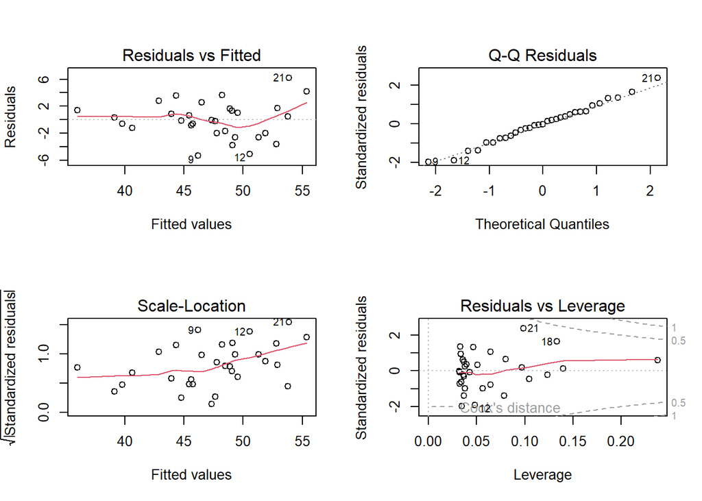

```r
par(mfrow = c(2,2))
plot(model_2)
```

### RunTime and RestPulse Model

```r
model_3 <- lm(Oxygen ~ RunTime + RestPulse, data=data)

summary(model_3)
```

```
##
## Call:
## lm(formula = Oxygen ~ RunTime + RestPulse, data = data)
##
## Residuals:
##     Min      1Q  Median      3Q     Max
## -5.3096 -1.8365 -0.1078  1.5321  6.1974
##
## Coefficients:
##              Estimate Std. Error t value Pr(>|t|)
## (Intercept) 82.685766   4.422808  18.695  < 2e-16 ***
## RunTime     -3.286609   0.411586  -7.985 1.07e-08 ***
## RestPulse   -0.009682   0.074945  -0.129    0.898
## ---
## Signif. codes:  0 '***' 0.001 '**' 0.01 '*' 0.05 '.' 0.1 ' ' 1
##
## Residual standard error: 2.793 on 28 degrees of freedom
## Multiple R-squared:  0.7435, Adjusted R-squared:  0.7252
## F-statistic: 40.59 on 2 and 28 DF,  p-value: 5.326e-09
```

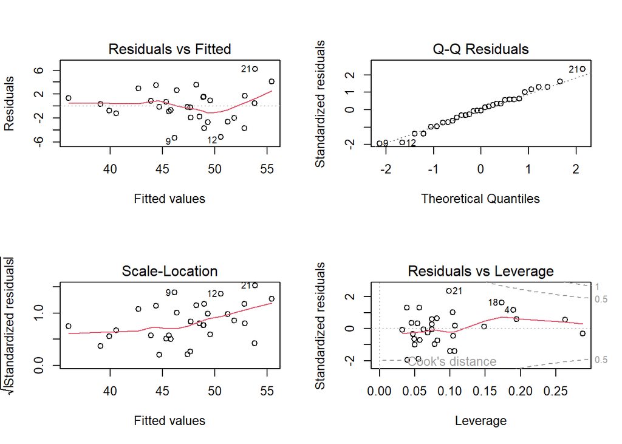

```r
par(mfrow = c(2,2))
plot(model_3)
```

### RunTime and RunPulse Model

```r
model_4 <- lm(Oxygen ~ RunTime + RunPulse, data=data)

summary(model_4)
```

```
##
## Call:
## lm(formula = Oxygen ~ RunTime + RunPulse, data = data)
##
## Residuals:
##     Min      1Q  Median      3Q     Max
## -5.5181 -1.2014 -0.4654  1.4569  6.5627
##
## Coefficients:
##             Estimate Std. Error t value Pr(>|t|)
## (Intercept) 93.08877    8.24882  11.285 6.26e-12 ***
## RunTime     -3.14019    0.37326  -8.413 3.77e-09 ***
## RunPulse    -0.07351    0.05051  -1.455    0.157
## ---
## Signif. codes:  0 '***' 0.001 '**' 0.01 '*' 0.05 '.' 0.1 ' ' 1
##
## Residual standard error: 2.693 on 28 degrees of freedom
## Multiple R-squared:  0.7614, Adjusted R-squared:  0.7444
## F-statistic: 44.68 on 2 and 28 DF,  p-value: 1.935e-09
```

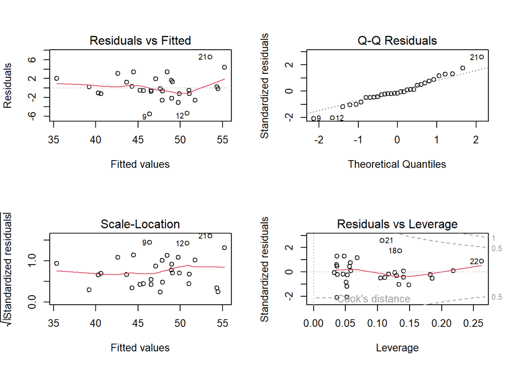

```r
par(mfrow = c(2,2))
plot(model_4)
```

### RunTime and Age Model

```r
model_5 <- lm(Oxygen ~ RunTime + Age, data=data)

summary(model_5)
```

```
##
## Call:
## lm(formula = Oxygen ~ RunTime + Age, data = data)
##
## Residuals:
##     Min      1Q  Median      3Q     Max
## -4.8744 -1.5443  0.1273  1.5575  4.9567
##
## Coefficients:
##             Estimate Std. Error t value Pr(>|t|)
## (Intercept) 88.46229    5.37264  16.465 6.21e-16 ***
## RunTime     -3.20395    0.35877  -8.930 1.10e-09 ***
## Age         -0.15037    0.09551  -1.574    0.127
## ---
## Signif. codes:  0 '***' 0.001 '**' 0.01 '*' 0.05 '.' 0.1 ' ' 1
##
## Residual standard error: 2.677 on 28 degrees of freedom
## Multiple R-squared:  0.7642, Adjusted R-squared:  0.7474
## F-statistic: 45.38 on 2 and 28 DF,  p-value: 1.638e-09
```

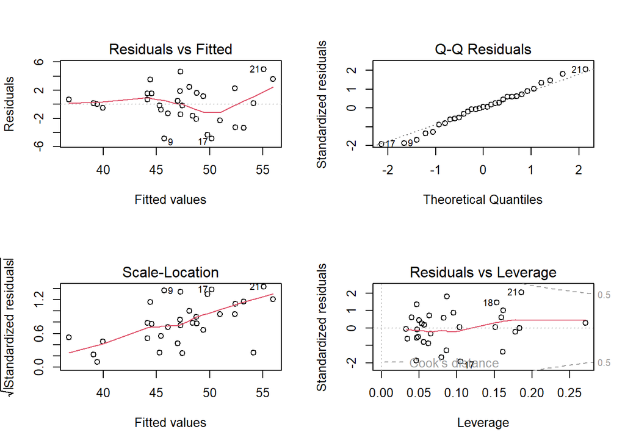

```r
par(mfrow = c(2,2))
plot(model_5)
```

The red line in the Scale-Location plot is not horizontal (can be a sign of *heteroscedasticity*).

### RunTime and Weight Model

```r
model_6 <- lm(Oxygen ~ RunTime + Weight, data=data)

summary(model_6)
```

```
##
## Call:
## lm(formula = Oxygen ~ RunTime + Weight, data = data)
##
## Residuals:
##     Min      1Q  Median      3Q     Max
## -5.5423 -1.5253  0.1175  1.5754  6.3590
##
## Coefficients:
##             Estimate Std. Error t value Pr(>|t|)
## (Intercept) 84.16298    5.75025  14.636 1.20e-14 ***
## RunTime     -3.28860    0.37031  -8.881 1.24e-09 ***
## Weight      -0.02548    0.06169  -0.413    0.683
## ---
## Signif. codes:  0 '***' 0.001 '**' 0.01 '*' 0.05 '.' 0.1 ' ' 1
##
## Residual standard error: 2.785 on 28 degrees of freedom
## Multiple R-squared:  0.7449, Adjusted R-squared:  0.7267
## F-statistic: 40.89 on 2 and 28 DF,  p-value: 4.933e-09
```

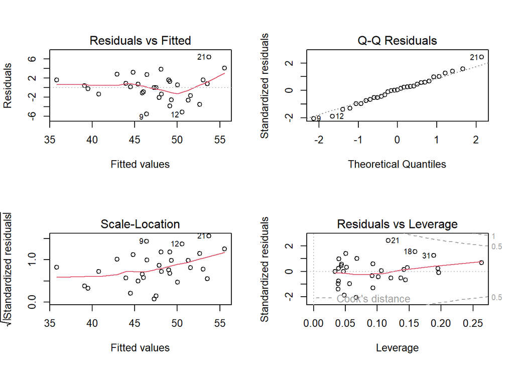

```r
par(mfrow = c(2,2))
plot(model_6)
```

### RunTime and MaxPulse Model

```r
model_7 <- lm(Oxygen ~ RunTime + MaxPulse, data=data)

summary(model_7)
```

```
##
## Call:
## lm(formula = Oxygen ~ RunTime + MaxPulse, data = data)
##
## Residuals:
##     Min      1Q  Median      3Q     Max
## -5.3945 -1.7072  0.0089  1.4206  6.5912
##
## Coefficients:
##             Estimate Std. Error t value Pr(>|t|)
## (Intercept) 86.46649    9.80533   8.818 1.43e-09 ***
## RunTime     -3.27232    0.37600  -8.703 1.88e-09 ***
## MaxPulse    -0.02561    0.05693  -0.450    0.656
## ---
## Signif. codes:  0 '***' 0.001 '**' 0.01 '*' 0.05 '.' 0.1 ' ' 1
##
## Residual standard error: 2.783 on 28 degrees of freedom
## Multiple R-squared:  0.7452, Adjusted R-squared:  0.727
## F-statistic: 40.95 on 2 and 28 DF,  p-value: 4.856e-09
```

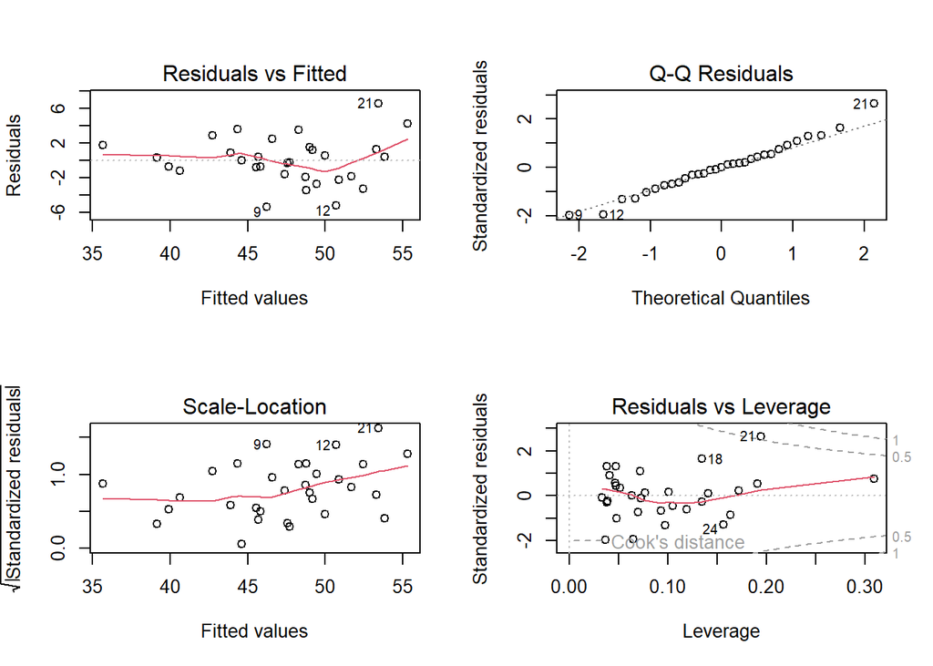

```r
par(mfrow = c(2,2))
plot(model_7)
```

### RunTime, RunPulse and Weight Model

```r
model_8 <- lm(Oxygen ~ RunTime + RunPulse + Weight, data=data)

summary(model_8)
```

```
##
## Call:
## lm(formula = Oxygen ~ RunTime + RunPulse + Weight, data = data)
##
## Residuals:
##     Min      1Q  Median      3Q     Max
## -5.6210 -1.1430 -0.4223  1.4074  6.6351
##
## Coefficients:
##             Estimate Std. Error t value Pr(>|t|)
## (Intercept) 93.75255    8.94621  10.480 5.15e-11 ***
## RunTime     -3.13261    0.38143  -8.213 8.09e-09 ***
## RunPulse    -0.07189    0.05195  -1.384    0.178
## Weight      -0.01315    0.06135  -0.214    0.832
## ---
## Signif. codes:  0 '***' 0.001 '**' 0.01 '*' 0.05 '.' 0.1 ' ' 1
##
## Residual standard error: 2.74 on 27 degrees of freedom
## Multiple R-squared:  0.7618, Adjusted R-squared:  0.7354
## F-statistic: 28.79 on 3 and 27 DF,  p-value: 1.455e-08
```

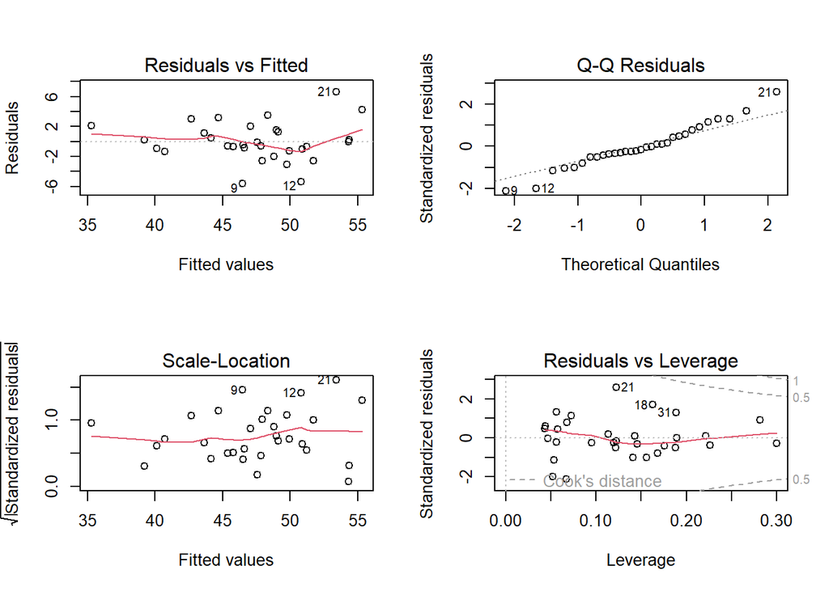

```r
par(mfrow = c(2,2))
plot(model_8)
```

### RunTime, RunPulse and Age Model

```r
model_9 <- lm(Oxygen ~ RunTime + RunPulse + Age, data=data)

summary(model_9)
```

```
##
## Call:
## lm(formula = Oxygen ~ RunTime + RunPulse + Age, data = data)
##
## Residuals:
##     Min      1Q  Median      3Q     Max
## -4.8752 -1.2493  0.2606  1.0324  4.8994
##
## Coefficients:
##              Estimate Std. Error t value Pr(>|t|)
## (Intercept) 111.71806   10.23509  10.915 2.10e-11 ***
## RunTime      -2.82538    0.35828  -7.886 1.77e-08 ***
## RunPulse     -0.13091    0.05059  -2.588   0.0154 *
## Age          -0.25640    0.09623  -2.664   0.0129 *
## ---
## Signif. codes:  0 '***' 0.001 '**' 0.01 '*' 0.05 '.' 0.1 ' ' 1
##
## Residual standard error: 2.441 on 27 degrees of freedom
## Multiple R-squared:  0.8111, Adjusted R-squared:  0.7901
## F-statistic: 38.64 on 3 and 27 DF,  p-value: 6.557e-10
```

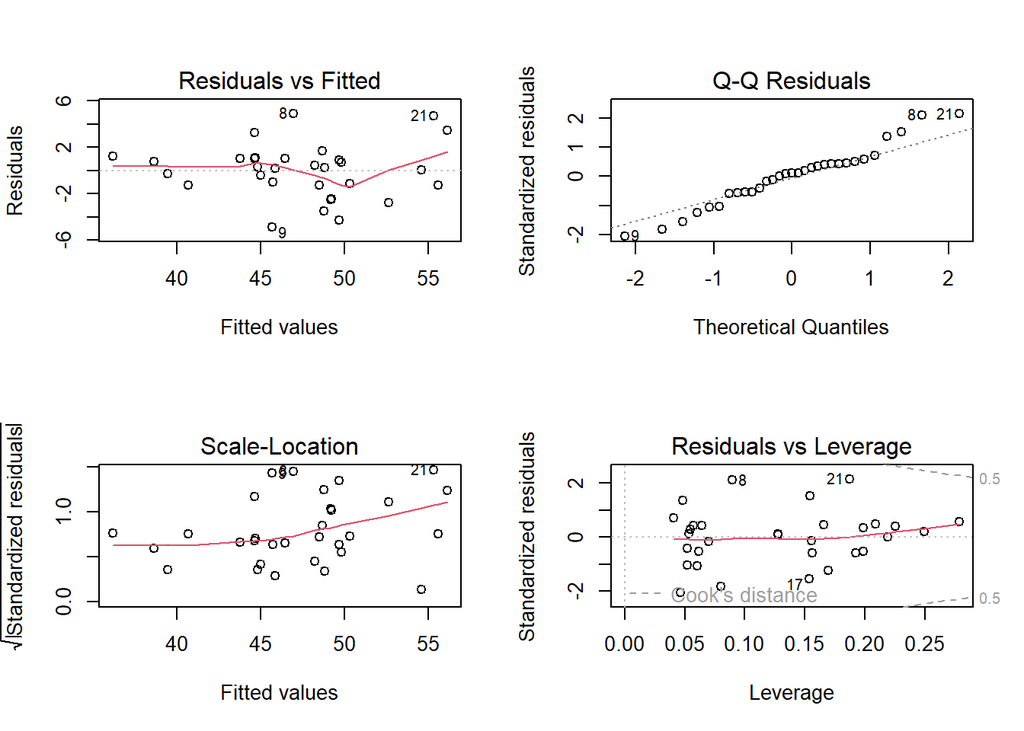

```r
par(mfrow = c(2,2))
plot(model_9)
```

### RunTime, RunPulse and MaxPulse Model

```r
model_10 <- lm(Oxygen ~ RunTime + RunPulse + MaxPulse, data=data)

summary(model_10)
```

```
##
## Call:
## lm(formula = Oxygen ~ RunTime + RunPulse + MaxPulse, data = data)
##
## Residuals:
##     Min      1Q  Median      3Q     Max
## -5.4477 -1.2391 -0.0799  1.5495  4.2799
##
## Coefficients:
##             Estimate Std. Error t value Pr(>|t|)
## (Intercept)  80.9008     8.8162   9.176 8.68e-10 ***
## RunTime      -2.9702     0.3453  -8.601 3.25e-09 ***
## RunPulse     -0.3751     0.1236  -3.034  0.00529 **
## MaxPulse      0.3542     0.1348   2.627  0.01403 *
## ---
## Signif. codes:  0 '***' 0.001 '**' 0.01 '*' 0.05 '.' 0.1 ' ' 1
##
## Residual standard error: 2.448 on 27 degrees of freedom
## Multiple R-squared:   0.81,  Adjusted R-squared:  0.7889
## F-statistic: 38.37 on 3 and 27 DF,  p-value: 7.09e-10
```

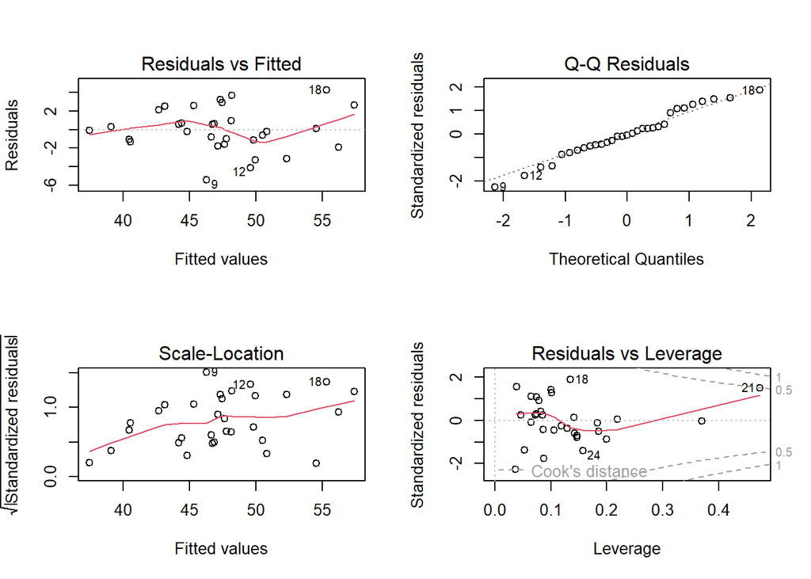

```r
par(mfrow = c(2,2))
plot(model_10)
```

### RunTime, RunPulse, MaxPulse and Age Model

```r
model_11 <- lm(Oxygen ~ RunTime + RunPulse + MaxPulse + Age, data=data)

summary(model_11)
```

```
##
## Call:
## lm(formula = Oxygen ~ RunTime + RunPulse + MaxPulse + Age, data = data)
##
## Residuals:
##     Min      1Q  Median      3Q     Max
## -4.9685 -1.1654 -0.0636  1.2004  4.7726
##
## Coefficients:
##             Estimate Std. Error t value Pr(>|t|)
## (Intercept) 98.14789   11.78569   8.328 8.26e-09 ***
## RunTime     -2.76758    0.34054  -8.127 1.31e-08 ***
## RunPulse    -0.34811    0.11750  -2.963  0.00644 **
## MaxPulse     0.27051    0.13362   2.024  0.05330 .
## Age         -0.19773    0.09564  -2.068  0.04877 *
## ---
## Signif. codes:  0 '***' 0.001 '**' 0.01 '*' 0.05 '.' 0.1 ' ' 1
##
## Residual standard error: 2.312 on 26 degrees of freedom
## Multiple R-squared:  0.8368, Adjusted R-squared:  0.8117
## F-statistic: 33.33 on 4 and 26 DF,  p-value: 6.91e-10
```

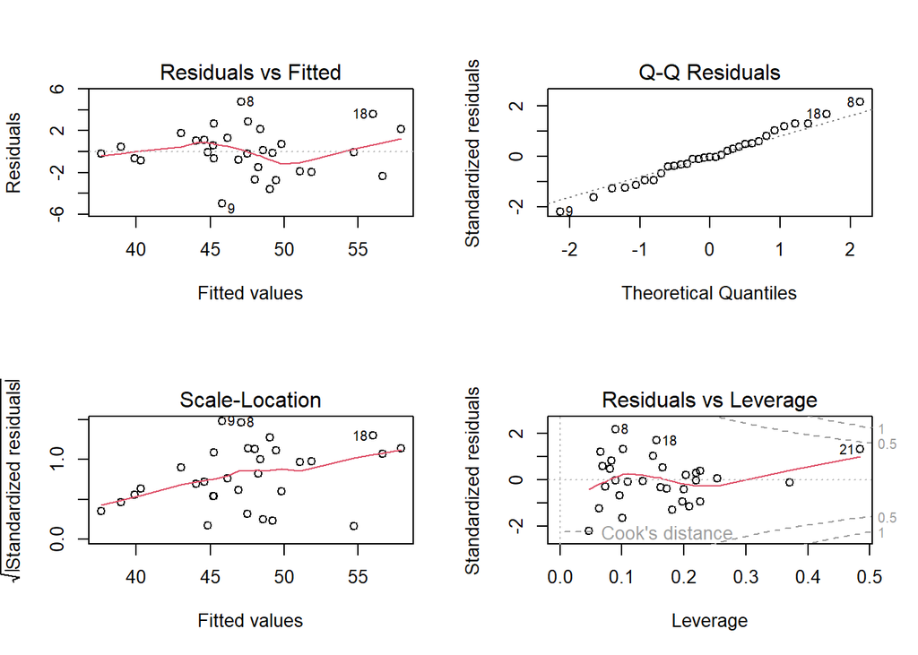

```r
par(mfrow = c(2,2))
plot(model_11)
```

```r
anova(model_11)
```

|  | Df | Sum Sq | Mean Sq | F value | Pr(>F) |
| --- | --- | --- | --- | --- | --- |
| RunTime | 1 | 632.90010 | 632.900100 | 118.443824 | 3.536660e-11 |
| RunPulse | 1 | 15.36208 | 15.362082 | 2.874930 | 1.019135e-01 |
| MaxPulse | 1 | 41.34703 | 41.347030 | 7.737873 | 9.929654e-03 |
| Age | 1 | 22.84231 | 22.842315 | 4.274815 | 4.876829e-02 |
| Residuals | 26 | 138.93002 | 5.343462 | NA | NA |

### RunTime, RunPulse, $e^{MaxPulse}$ and Age Model

```r
data$exp_MaxPulse <- exp(data$MaxPulse)

model_12 <- lm(Oxygen ~ RunTime + exp_MaxPulse + RunPulse + Age, data=data)
summary(model_12)
```

```
##
## Call:
## lm(formula = Oxygen ~ RunTime + exp_MaxPulse + RunPulse + Age,
##     data = data)
##
## Residuals:
##     Min      1Q  Median      3Q     Max
## -4.8147 -1.2137  0.2029  1.0726  4.8677
##
## Coefficients:
##                Estimate Std. Error t value Pr(>|t|)
## (Intercept)   1.129e+02  1.057e+01  10.687 5.23e-11 ***
## RunTime      -2.924e+00  3.994e-01  -7.320 8.97e-08 ***
## exp_MaxPulse  7.049e-84  1.200e-83   0.587   0.5621
## RunPulse     -1.346e-01  5.159e-02  -2.608   0.0149 *
## Age          -2.484e-01  9.837e-02  -2.525   0.0180 *
## ---
## Signif. codes:  0 '***' 0.001 '**' 0.01 '*' 0.05 '.' 0.1 ' ' 1
##
## Residual standard error: 2.471 on 26 degrees of freedom
## Multiple R-squared:  0.8136, Adjusted R-squared:  0.7849
## F-statistic: 28.37 on 4 and 26 DF,  p-value: 3.805e-09
```

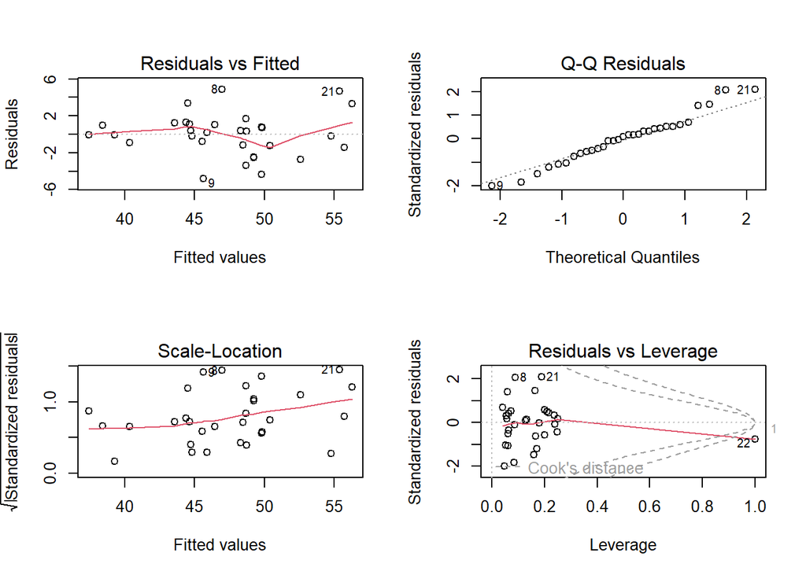

```r
par(mfrow = c(2,2))
plot(model_12)
```

```r
anova(model_12)
```

|  | Df | Sum Sq | Mean Sq | F value | Pr(>F) |
| --- | --- | --- | --- | --- | --- |
| RunTime | 1 | 632.900100 | 632.900100 | 103.6720500 | 1.454484e-10 |
| exp_MaxPulse | 1 | 2.342233 | 2.342233 | 0.3836689 | 5.410366e-01 |
| RunPulse | 1 | 18.484954 | 18.484954 | 3.0279235 | 9.366855e-02 |
| Age | 1 | 38.928714 | 38.928714 | 6.3767087 | 1.799828e-02 |
| Residuals | 26 | 158.725545 | 6.104829 | NA | NA |

## Testing the Regression Assumptions

```r
model <- model_9
```

### Breusch-Pagan Test

```r
bptest(model)
```

```
##
##  studentized Breusch-Pagan test
##
## data:  model
## BP = 2.944, df = 3, p-value = 0.4003
```

$H_0$: the residuals are homoscedastic

$H_A$: the residuals are heteroscedastic

The p-value is greater than 0.05, so we fail to reject the null hypothesis. Therefore, the assumption for **homoscedasticity** holds.

### Durbin-Watson Test

```r
dwtest(model)
```

```
##
##  Durbin-Watson test
##
## data:  model
## DW = 2.2658, p-value = 0.7391
## alternative hypothesis: true autocorrelation is greater than 0
```

$H_0$: the autocorrelation is 0

$H_A$: the autocorrelation is greater than 0

The p-value is greater than 0.05, so we fail to reject the null hypothesis. Therefore, there is **no evidence of autocorrelation**.

### Variance Inflation Factors

```r
vif(model)
```

```
##  RunTime RunPulse      Age
## 1.244441 1.354763 1.266611
```

There is **no multicollinearity** between the predictors.

### Shapiro Test

```r
shapiro.test(residuals(model))
```

```
##
##  Shapiro-Wilk normality test
##
## data:  residuals(model)
## W = 0.96735, p-value = 0.4492
```

$H_0$: the residuals are normally distributed

$H_A$: the residuals are not normally distributed

The p-value is greater than 0.05, so we fail to reject the null hypothesis. We can assume that the residuals are **normally distributed**.

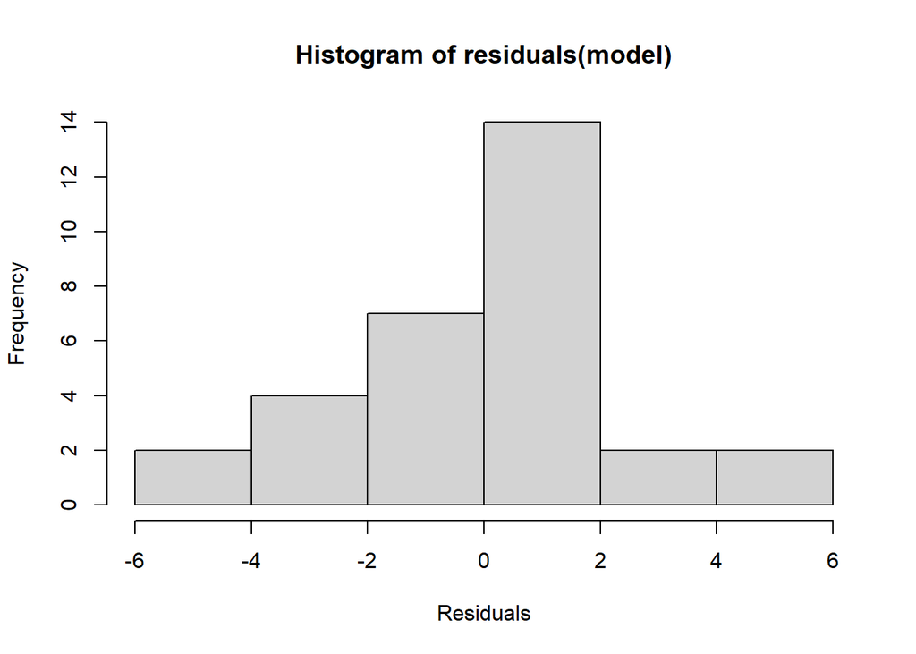

```r
hist(
  residuals(model),
  xlab='Residuals'
)
```